# FA6

Paul Joaquin M. Delos Santos

2024-02-22

## Question (1)

I. Geometric Distribution. Provide an R code for the geometric distribution. The geometric distribution is a probability distribution that models the number of trials required to achieve the first success in a sequence of Bernoulli trials, where each trial has a constant probability of success.

1. Set the probability of success: p <- 0.2
2. Generate 1000 random variables from the geometric distribution.
3. Calculate some basic statistics:

mean_x <- mean(x)

var_x <- var(x)

sd_x <- sd(x) 4. Print the results in item 3 with the following output (string):

Number of trials required to achieve first success:

Mean (in 2 decimal places):

Variance (in 2 decimal places):

Standard deviation ( in 2 decimal places):

5. Plot the histogram of the results.

```
## Number of trials required to achieve first success:
```

```
## Mean (in 2 decimal places):  3.83
```

```
## Variance (in 2 decimal places):  17.57
```

```
## Standard deviation (in 2 decimal places):  4.19
```

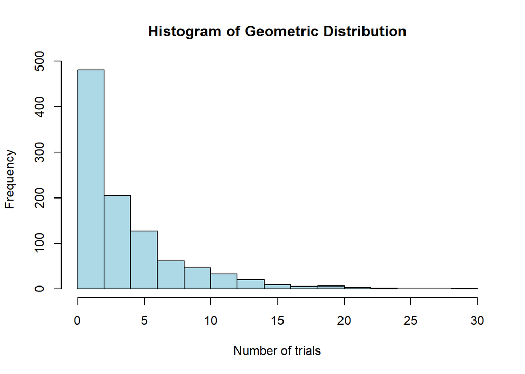

## Question (2)

2. Hypergeometric Distribution. Consider a plant manufacturing IC chips of which 10% are expected to be defective. The chips are packed in boxes for export. Before transportation, a sample is drawn from each box. Estimate the probability that the sample contains more than 10% defectives, when:

1.) A sample of 10 is selected from a box of 40;

2.) A sample of 10 is selected from a box of 5000.

[output not shown]

[output not shown]